# Module 2

# The *Marketing Plan*

1. What is the expected sales if our client spends 150K on TV, 20K on Radio, and 30K on Newspaper?
2. The client is planning to spend $100K in total advertising for a single market. How do you recommend they allocate that budget over the three media? What is the expected sales using your optimal strategy?
3. How would you communicate to the client the uncertainty in the sales that will result from this experiment?
4. If the actual sales were 8000 units, how do you think the client would respond? How would you address the response from the client?

```r
#-- Packages
library(broom)      # for tidy model output
library(knitr)      # kable() for nicer table output
library(GGally)     # pairs plot ggpairs()
library(tidyverse)  # dplyr, ggplot2, etc
```

## Exploratory data analysis

### Load and preprocess data

The data file contains the rownames as the first column. `read_csv` makes it a new column named `...1`.

```r
#-- Load Data
url <- 'https://www.statlearning.com/s/Advertising.csv'
advert <- read_csv(url) %>%
  column_to_rownames('...1')
```

```
## ──────────────────────────────────────────────────────── Delimiter: "," dbl
## (5): ...1, TV, radio, newspaper, sales
```

### Summary

```r
#-- Show data
head(advert)
```

```
##      TV radio newspaper sales
## 1 230.1  37.8      69.2  22.1
## 2  44.5  39.3      45.1  10.4
## 3  17.2  45.9      69.3   9.3
## 4 151.5  41.3      58.5  18.5
## 5 180.8  10.8      58.4  12.9
## 6   8.7  48.9      75.0   7.2
```

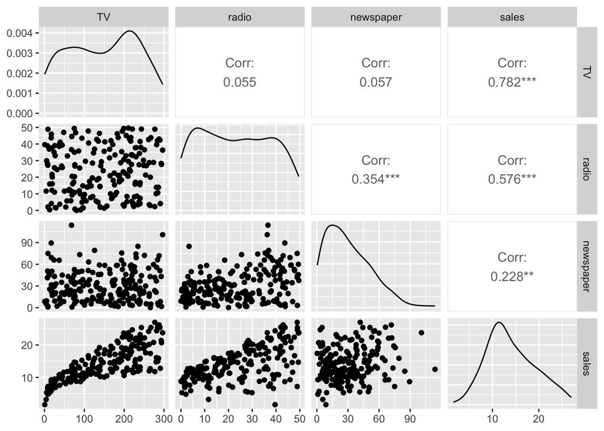

```r
library(GGally)
ggpairs(advert, progress=FALSE)
```

Convert the data from *wide* to *long* format for facetted graphs.

```r
advert_long <- pivot_longer(advert, cols=-sales,
                            names_to='predictor',
                            values_to='budget')
head(advert_long)
```

```
## # A tibble: 6 × 3
##   sales predictor budget
##   <dbl> <chr>      <dbl>
## 1  22.1 TV         230.
## 2  22.1 radio       37.8
## 3  22.1 newspaper   69.2
## 4  10.4 TV          44.5
## 5  10.4 radio       39.3
## 6  10.4 newspaper   45.1
```

Use `geom_smooth` to identify trends

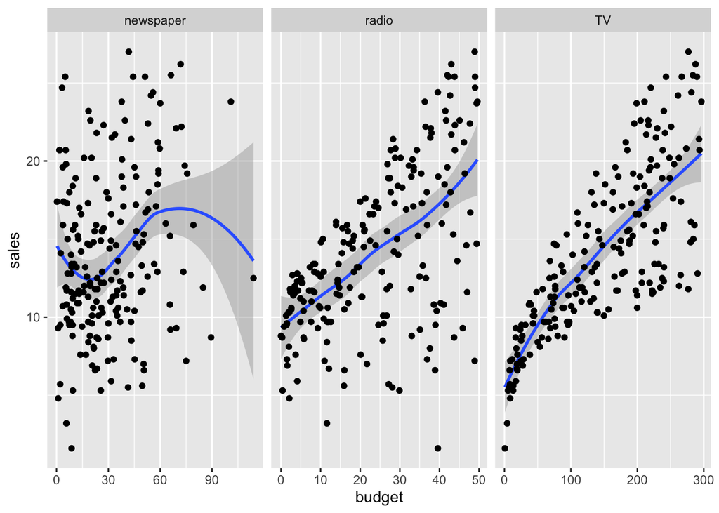

```r
ggplot(advert_long, aes(x=budget, y=sales)) +
  geom_smooth() +
  geom_point() +
  facet_wrap(~predictor, scales="free_x")
```

## Regression Models

### Three predictor model

Consider the advertising sales model that uses all three predictors
$$\text{sales} = \beta_0 + \beta_1 \times \text{(TV)} + \beta_2 \times
\text{(radio)} +
\beta_3 \times \text{(newspaper)} + \text{error}$$

In R, the formula would be `Sales ~ TV + Radio + Newspaper` (the order of the predictor variables does not matter).

```r
#- fit full (main effects) model
lm.all = lm(sales ~ TV + radio + newspaper,
            data=advert)

#- model summary
summary(lm.all)
```

```
##
## Call:
## lm(formula = sales ~ TV + radio + newspaper, data = advert)
##
## Residuals:
##     Min      1Q  Median      3Q     Max
## -8.8277 -0.8908  0.2418  1.1893  2.8292
##
## Coefficients:
##              Estimate Std. Error t value Pr(>|t|)
## (Intercept)  2.938889   0.311908   9.422   <2e-16 ***
## TV           0.045765   0.001395  32.809   <2e-16 ***
## radio        0.188530   0.008611  21.893   <2e-16 ***
## newspaper   -0.001037   0.005871  -0.177     0.86
## ---
## Signif. codes:  0 '***' 0.001 '**' 0.01 '*' 0.05 '.' 0.1 ' ' 1
##
## Residual standard error: 1.686 on 196 degrees of freedom
## Multiple R-squared:  0.8972, Adjusted R-squared:  0.8956
## F-statistic: 570.3 on 3 and 196 DF,  p-value: < 2.2e-16
```

```r
#- tidy output (coefficients)
lm.all %>%
  broom::tidy(conf.int=TRUE) %>%
  knitr::kable(digits=3)
```

| term | estimate | std.error | statistic | p.value | conf.low | conf.high |
| --- | --- | --- | --- | --- | --- | --- |
| (Intercept) | 2.939 | 0.312 | 9.422 | 0.00 | 2.324 | 3.554 |
| TV | 0.046 | 0.001 | 32.809 | 0.00 | 0.043 | 0.049 |
| radio | 0.189 | 0.009 | 21.893 | 0.00 | 0.172 | 0.206 |
| newspaper | -0.001 | 0.006 | -0.177 | 0.86 | -0.013 | 0.011 |

```r
#- tidy model summary
lm.all %>%
  broom::glance() %>%
  knitr::kable(digits=3)
```

| r.squared | adj.r.squared | sigma | statistic | p.value | df | logLik | AIC | BIC | deviance | df.residual | nobs |
| --- | --- | --- | --- | --- | --- | --- | --- | --- | --- | --- | --- |
| 0.897 | 0.896 | 1.686 | 570.271 | 0 | 3 | -386.181 | 782.362 | 798.854 | 556.825 | 196 | 200 |

```r
pred_data = tibble(TV=150, radio=20, newspaper=30)
predict(lm.all,
        newdata=pred_data,
        interval="prediction") # or "confidence"
```

```
##        fit      lwr      upr
## 1 13.54306 10.21025 16.87587
```

### Simpler Model

Note that `newspaper` is not statistically significant. We can therefore create a reduced model.

```r
#-- Only TV + Radio
lm.TVRadio = lm(sales ~ TV + radio,
                data=advert)
summary(lm.TVRadio)
```

```
##
## Call:
## lm(formula = sales ~ TV + radio, data = advert)
##
## Residuals:
##     Min      1Q  Median      3Q     Max
## -8.7977 -0.8752  0.2422  1.1708  2.8328
##
## Coefficients:
##             Estimate Std. Error t value Pr(>|t|)
## (Intercept)  2.92110    0.29449   9.919   <2e-16 ***
## TV           0.04575    0.00139  32.909   <2e-16 ***
## radio        0.18799    0.00804  23.382   <2e-16 ***
## ---
## Signif. codes:  0 '***' 0.001 '**' 0.01 '*' 0.05 '.' 0.1 ' ' 1
##
## Residual standard error: 1.681 on 197 degrees of freedom
## Multiple R-squared:  0.8972, Adjusted R-squared:  0.8962
## F-statistic: 859.6 on 2 and 197 DF,  p-value: < 2.2e-16
```

## Interaction Effects

We have found that the best model so far is the one that uses `TV` and `Radio` to predict the value of `Sales`.

Specifically, the least squares model is:

$$\widehat{\text{sales}} = 2.921 + 0.046
\times \text{(TV)} + 0.188 \times \text{(radio)}$$

- So a one unit increase in `TV` would suggest a 0.046 unit increase in `Sales`, no matter the budget allocated to `Radio`
- But what if spending money on `Radio` advertising actually increases the effectiveness of the `TV` advertising?
  - So `TV` effects should increase as `Radio` increases
  - E.g., spending 1/2 of a $100,000 budget on `TV` and `Radio` may increase `Sales` more than allocating the entire amount to only `TV` or only `Radio`
  - In marketing, this is the *synergy* effect. In statistics, this is known as an *interaction* effect.

### Modeling Interactions

Consider the linear regression model with two variables and an interaction effect

$$Y = \beta_0 + \beta_1 X_1 + \beta_2 X_2
+ \beta_3 X_1 X_2 + \epsilon$$

This model relaxes the additive structure, while maintaining the linear structure. Consider the equation re-written

$$\begin{align*}
Y &= \beta_0 + (\beta_1 + \beta_3 X_2)X_1 + \beta_2 X_2 + \epsilon
\\
&= \beta_0 + \tilde{\beta}_1 X_1 + \beta_2 X_2 + \epsilon
\end{align*}$$
where $\tilde{\beta}_1 = (\beta_1 + \beta_3 X_2)$.

- Since $\tilde{\beta}_1$ changes with $X_2$, the effect of $X_1$ on $Y$ is no longer constant.
  - Adjusting $X_2$ will change the impact of $X_1$ on $Y$

In R, use the notation `X_1:X_2` to include an interaction effect:

```r
lm.synergy = lm(sales ~ TV + radio + TV:radio,
                data=advert)
summary(lm.synergy)
```

```
##
## Call:
## lm(formula = sales ~ TV + radio + TV:radio, data = advert)
##
## Residuals:
##     Min      1Q  Median      3Q     Max
## -6.3366 -0.4028  0.1831  0.5948  1.5246
##
## Coefficients:
##              Estimate Std. Error t value Pr(>|t|)
## (Intercept) 6.750e+00  2.479e-01  27.233   <2e-16 ***
## TV          1.910e-02  1.504e-03  12.699   <2e-16 ***
## radio       2.886e-02  8.905e-03   3.241   0.0014 **
## TV:radio    1.086e-03  5.242e-05  20.727   <2e-16 ***
## ---
## Signif. codes:  0 '***' 0.001 '**' 0.01 '*' 0.05 '.' 0.1 ' ' 1
##
## Residual standard error: 0.9435 on 196 degrees of freedom
## Multiple R-squared:  0.9678, Adjusted R-squared:  0.9673
## F-statistic:  1963 on 3 and 196 DF,  p-value: < 2.2e-16
```

```r
coef(lm.TVRadio)
```

```
## (Intercept)          TV       radio
##  2.92109991  0.04575482  0.18799423
```

```r
coef(lm.synergy)
```

```
## (Intercept)          TV       radio    TV:radio
## 6.750220203 0.019101074 0.028860340 0.001086495
```

## Prediction

In R, the `predict()` function will return the predicted values from a fitted regression model. Besides the model, the function needs the $X$ values (the `newdata` argument) for making predictions.  
- Type `?predict.lm` to read the help pages  
- The `object` argument is the `lm` model  
- The `newdata` must be a `data.frame`/`tibble`

```r
#-- predict the Sales for a budget with TV = 50
#   ($50,000) and Radio = 20 ($20,000)
pred_data = tibble(TV=50, radio=20, newspaper=0)
predict(lm.TVRadio,
        newdata=pred_data,
        interval="prediction") # or "confidence"
```

```
##        fit      lwr      upr
## 1 8.968725 5.633862 12.30359
```

```r
predict(lm.synergy,
        newdata=pred_data,
        interval="prediction") # or "confidence"
```

```
##        fit      lwr      upr
## 1 9.368975 7.497131 11.24082
```

Multiple values (grid of predictor values)

```r
pred_grid =
  expand_grid(TV=seq(0, 50, by=25),
              radio=seq(0, 60, by=20),
              newspaper=0)
bind_cols(
  pred_grid,
  predict(lm.TVRadio,
        newdata=pred_grid,
        interval="prediction") %>%
    as_tibble()
)
```

```
## # A tibble: 12 × 6
##       TV radio newspaper   fit    lwr   upr
##    <dbl> <dbl>     <dbl> <dbl>  <dbl> <dbl>
##  1     0     0         0  2.92 -0.445  6.29
##  2     0    20         0  6.68  3.33  10.0
##  3     0    40         0 10.4   7.08  13.8
##  4     0    60         0 14.2  10.8   17.6
##  5    25     0         0  4.06  0.706  7.42
##  6    25    20         0  7.82  4.48  11.2
##  7    25    40         0 11.6   8.23  14.9
##  8    25    60         0 15.3  12.0   18.7
##  9    50     0         0  5.21  1.86   8.56
## 10    50    20         0  8.97  5.63  12.3
## 11    50    40         0 12.7   9.38  16.1
## 12    50    60         0 16.5  13.1   19.9
```

Allocating $100K budget

```r
lm.TV <- lm(sales ~ TV, data=advert)
lm.radio <- lm(sales ~ radio, data=advert)
```

```r
budgetTV <- seq(0, 100, by=5)
budget = tibble(TV=budgetTV, radio=100-budgetTV)

result <- bind_cols(
  budget,
  tibble(TVmodel=predict(lm.TV, newdata=budget)),
  tibble(radioModel=predict(lm.radio, newdata=budget)),
  tibble(TVRadio=predict(lm.TVRadio, newdata=budget)),
  tibble(Synergy=predict(lm.synergy, newdata=budget)),
)
result
```

```
## # A tibble: 21 × 6
##       TV radio TVmodel radioModel TVRadio Synergy
##    <dbl> <dbl>   <dbl>      <dbl>   <dbl>   <dbl>
##  1     0   100    7.03       29.6    21.7    9.64
##  2     5    95    7.27       28.5    21.0   10.1
##  3    10    90    7.51       27.5    20.3   10.5
##  4    15    85    7.75       26.5    19.6   10.9
##  5    20    80    7.98       25.5    18.9   11.2
##  6    25    75    8.22       24.5    18.2   11.4
##  7    30    70    8.46       23.5    17.5   11.6
##  8    35    65    8.70       22.5    16.7   11.8
##  9    40    60    8.93       21.5    16.0   11.9
## 10    45    55    9.17       20.4    15.3   11.9
## # … with 11 more rows
```

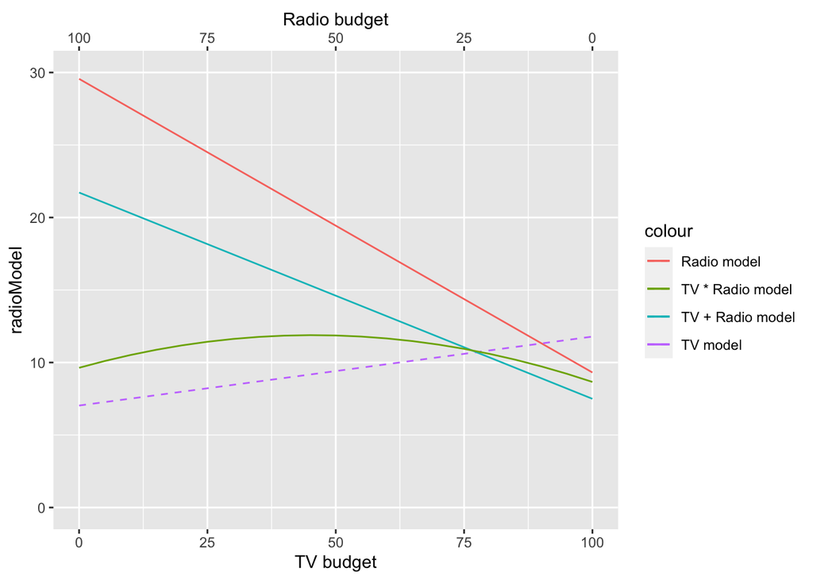

```r
ggplot(result, aes(x=TV)) +
  geom_line(aes(y=radioModel, color='Radio model')) +
  geom_line(aes(y=TVmodel, color='TV model'), linetype='dashed') +
  geom_line(aes(y=TVRadio, color='TV + Radio model')) +
  geom_line(aes(y=Synergy, color='TV * Radio model')) +
  ylim(0, 30) +
  scale_x_continuous("TV budget", sec.axis = sec_axis(~ 100 - ., name = 'Radio budget'))
```

# Building linear regression models

## base-R

Formula interface

```
model <- lm(formula, data=df)

lm.radio <- lm(sales ~ radio, data=advert)
```

Design matrix (predictors) and outcome

```
model <- lm(pedictors, outcome)
```

## Caret

The package `caret` has a general `train` function that provides a consistent interface to over 200 different methods (see https://topepo.github.io/caret/available-models.html). Like the `lm` command, the `train` function can be called with predictors `x` and outcome `y` or with a formula `formula` and `data`.

```
caret::train(x, y, method='lm')
caret::train(form, data, method='lm')
```

This however will do a cross-validation by default. To just train a model with the full dataset, use `trainControl`

```r
model <- caret::train(sales ~ TV + radio + TV:radio,
                      data=advert,
                      method='lm',
                      trControl=caret::trainControl(method='none'))
model
```

```
## Linear Regression
##
## 200 samples
##   2 predictor
##
## No pre-processing
## Resampling: None
```

You can still get the summary of the model information

```r
summary(model)
```

```
##
## Call:
## lm(formula = .outcome ~ ., data = dat)
##
## Residuals:
##     Min      1Q  Median      3Q     Max
## -6.3366 -0.4028  0.1831  0.5948  1.5246
##
## Coefficients:
##              Estimate Std. Error t value Pr(>|t|)
## (Intercept) 6.750e+00  2.479e-01  27.233   <2e-16 ***
## TV          1.910e-02  1.504e-03  12.699   <2e-16 ***
## radio       2.886e-02  8.905e-03   3.241   0.0014 **
## `TV:radio`  1.086e-03  5.242e-05  20.727   <2e-16 ***
## ---
## Signif. codes:  0 '***' 0.001 '**' 0.01 '*' 0.05 '.' 0.1 ' ' 1
##
## Residual standard error: 0.9435 on 196 degrees of freedom
## Multiple R-squared:  0.9678, Adjusted R-squared:  0.9673
## F-statistic:  1963 on 3 and 196 DF,  p-value: < 2.2e-16
```

Using `model$finalModel` gives you access to the actual model and therefore many of the above functionality.

```r
coef(model$finalModel)
```

```
## (Intercept)          TV       radio  `TV:radio`
## 6.750220203 0.019101074 0.028860340 0.001086495
```

```r
model$finalModel %>%
  broom::glance() %>%
  knitr::kable(digits=3)
```

| r.squared | adj.r.squared | sigma | statistic | p.value | df | logLik | AIC | BIC | deviance | df.residual | nobs |
| --- | --- | --- | --- | --- | --- | --- | --- | --- | --- | --- | --- |
| 0.968 | 0.967 | 0.944 | 1963.057 | 0 | 3 | -270.139 | 550.278 | 566.769 | 174.483 | 196 | 200 |

Diagnostic plots

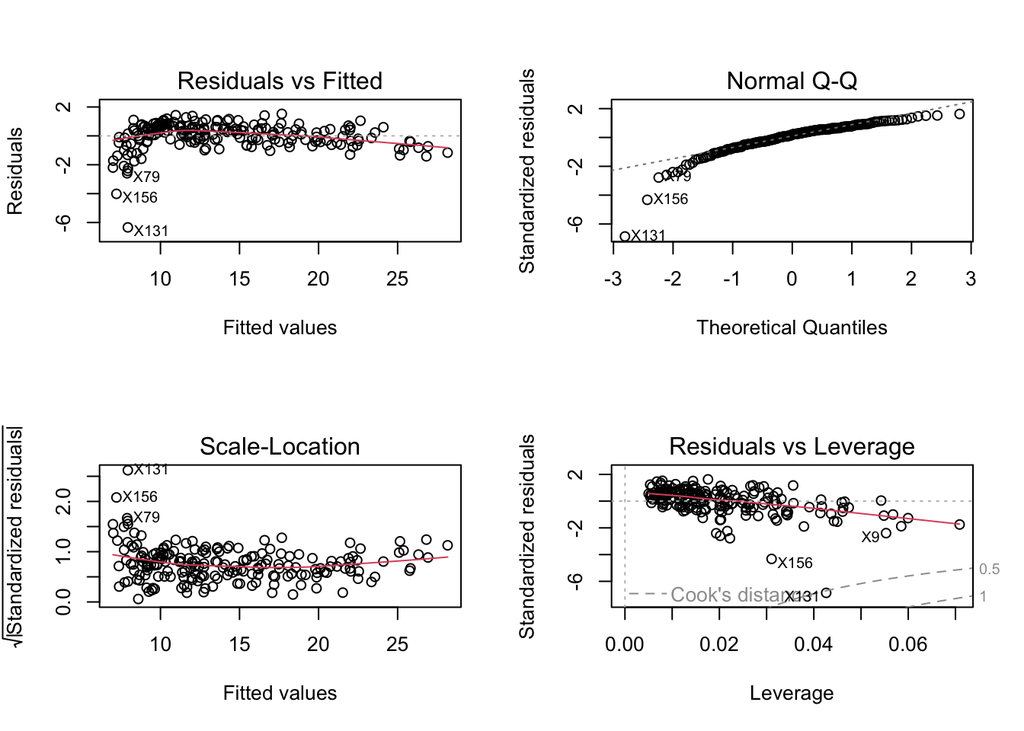

```r
par(mfrow=c(2, 2))
plot(model$finalModel)
```

And you can predict new data as follows:

```r
predict(model, pred_grid)
```

```
##         1         2         3         4         5         6         7         8
##  6.750220  7.327427  7.904634  8.481841  7.227747  8.348201  9.468655 10.589109
##         9        10        11        12
##  7.705274  9.368975 11.032677 12.696378
```

## And for the adventurous - tidymodels

Why? `tidymodels` is actively developed by RStudio and `caret` is not

Load the package

```r
library(tidymodels)
```

First define the model

```r
model <- linear_reg() %>%  # we want to do build a linear regression model
  set_engine('lm') # using the base-R lm model
```

and next fit the model to the data

```r
fit_mod <- model %>%
  fit(sales ~ TV + radio + TV:radio, data=advert)
fit_mod
```

```
## parsnip model object
##
##
## Call:
## stats::lm(formula = sales ~ TV + radio + TV:radio, data = data)
##
## Coefficients:
## (Intercept)           TV        radio     TV:radio
##    6.750220     0.019101     0.028860     0.001086
```

get details about the model

```r
tidy(fit_mod)
```

```
## # A tibble: 4 × 5
##   term        estimate std.error statistic  p.value
##   <chr>          <dbl>     <dbl>     <dbl>    <dbl>
## 1 (Intercept)  6.75    0.248         27.2  1.54e-68
## 2 TV           0.0191  0.00150       12.7  2.36e-27
## 3 radio        0.0289  0.00891        3.24 1.40e- 3
## 4 TV:radio     0.00109 0.0000524     20.7  2.76e-51
```

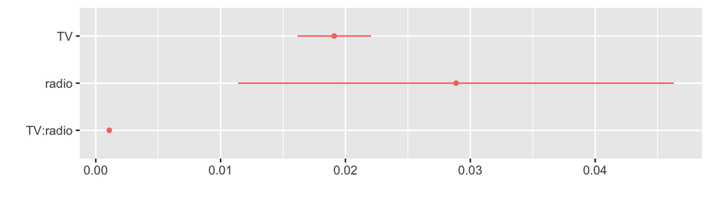

```r
library(dotwhisker)
tidy(fit_mod) %>% dwplot()
```

Predict new data

```r
predict(fit_mod, pred_grid)
```

```
## # A tibble: 12 × 1
##    .pred
##    <dbl>
##  1  6.75
##  2  7.33
##  3  7.90
##  4  8.48
##  5  7.23
##  6  8.35
##  7  9.47
##  8 10.6
##  9  7.71
## 10  9.37
## 11 11.0
## 12 12.7
```

and access the underlying model:

```r
coef(fit_mod$fit)
```

```
## (Intercept)          TV       radio    TV:radio
## 6.750220203 0.019101074 0.028860340 0.001086495
```